# individual2

Blake Inderski, btski

February 19, 2019

```r
HAPPY <- readRDS("HAPPY.rds")
#head(HAPPY)

library("ggplot2")
library("dplyr")
```

Answer each of the following questions using R code to get an answer. Write a separate code chunk to manipulate each variable. Once all the data manipulation is done, show the values in a barchart or histogram and comment on the plot. Use ggplot2 to create the plots.

1. Data cleaning: the values “IAP”, “DK” and “NA” all encode missing values. Replace all of these instances by the value NA.

```r
HAPPY[HAPPY=="IAP"|HAPPY=="DK"|HAPPY=="NA"] <- NA
#head(HAPPY)
```

2. Check the type of the variable and cast into the right type (factor variable for categorical variables). For age, change “89 OR OLDER” to 89 and assume the variable should be numeric. (Hint: see ?as.character and ?as.numeric)

```r
HAPPY$AGE[HAPPY$AGE=="89 OR OLDER"] <- 89
HAPPY <- transform(HAPPY, AGE = as.numeric(AGE))

HAPPY <- HAPPY %>%
  mutate_if(is.character, as.factor) %>%
  mutate_if(~ is.integer(.) | is.double(.), as.numeric)
#head(HAPPY)
```

3. Bring all levels of factors into a sensible order. For marital you could e.g. order the levels according to average age.

```r
HAPPY <- HAPPY %>%
  mutate(HAPPY = factor(HAPPY, c("NOT TOO HAPPY", "PRETTY HAPPY", "VERY HAPPY"))) %>%
  mutate(DEGREE = factor(DEGREE, c("LT HIGH SCHOOL", "HIGH SCHOOL", "JUNIOR COLLEGE", "BACHELOR", "GRADUATE" ))) %>%
  mutate(SEX = factor(SEX, c("FEMALE", "MALE"))) %>%
  mutate(FINRELA = factor(FINRELA, c("FAR BELOW AVERAGE", "BELOW AVERAGE", "AVERAGE", "ABOVE AVERAGE", "FAR ABOVE AVERAGE"))) %>%
  mutate(HEALTH = factor(HEALTH, c("POOR", "FAIR", "GOOD", "EXCELLENT"))) %>%
  mutate(PARTYID = factor(PARTYID, c("STRONG REPUBLICAN", "NOT STR REPUBLICAN", "IND,NEAR REP", "INDEPENDENT", "IND,NEAR DEM", "NOT STR DEMOCRAT", "STRONG DEMOCRAT", "OTHER PARTY"))) %>%
  mutate(POLVIEWS = factor(POLVIEWS, c("EXTRMLY CONSERVATIVE", "SLGHTLY CONSERVATIVE", "CONSERVATIVE", "MODERATE", "LIBERAL", "SLIGHTLY LIBERAL", "EXTREMELY LIBERAL")))

#MARITAL column has no obvious order
#sort by average age of aggregated/grouped MARITAL value
subset_marital_by_age <- aggregate(AGE ~ MARITAL, data = HAPPY, mean) %>%
  arrange(AGE)
HAPPY <- mutate(HAPPY, MARITAL = factor(MARITAL, as.vector(subset_marital_by_age$MARITAL)))
#sapply(HAPPY, levels)
```

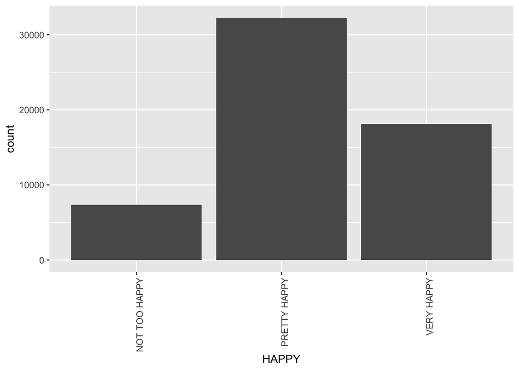

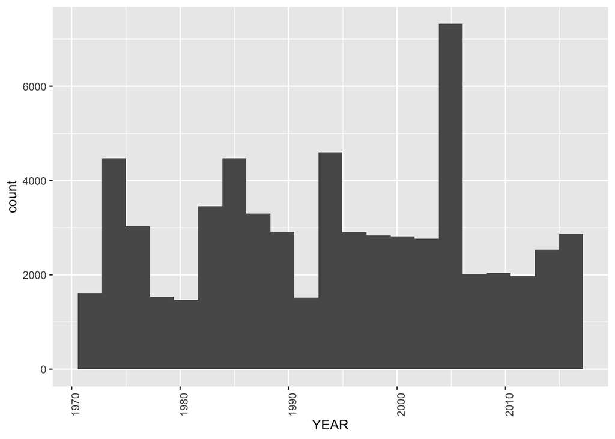

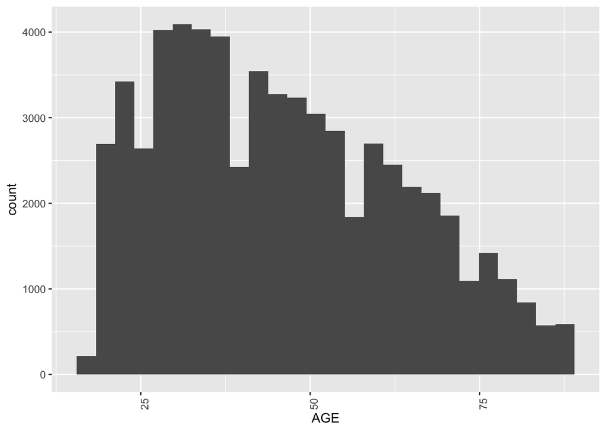

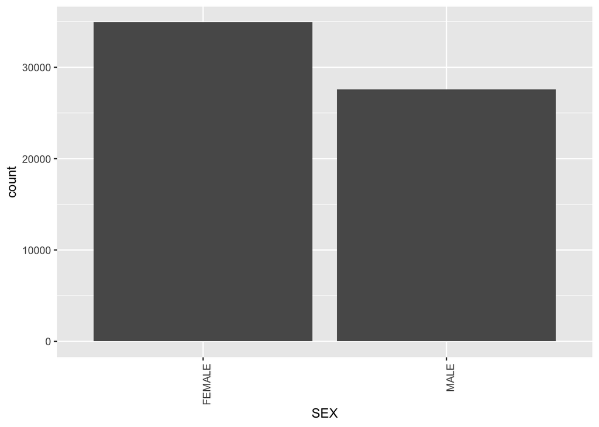

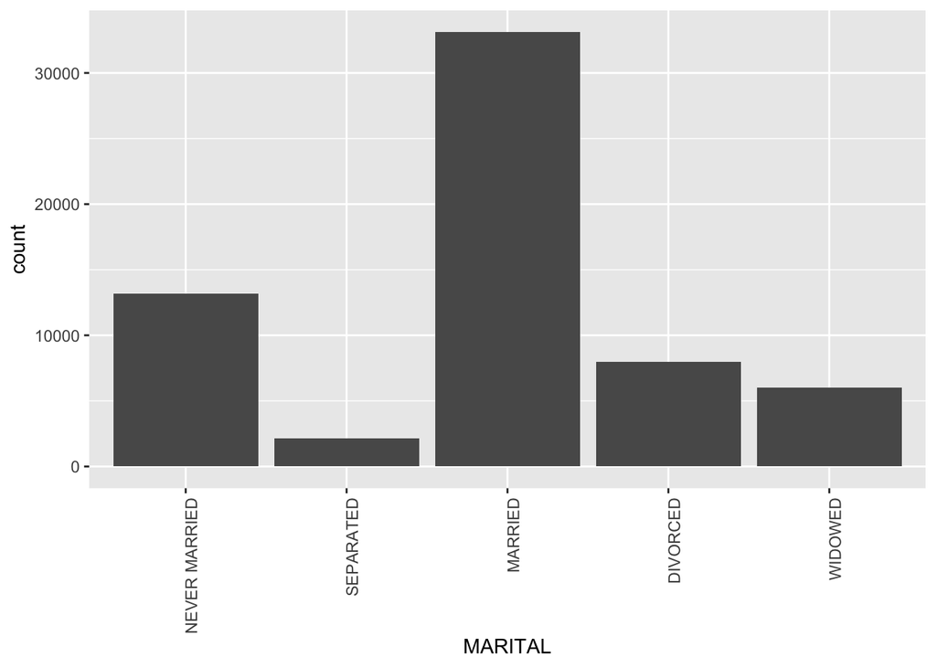

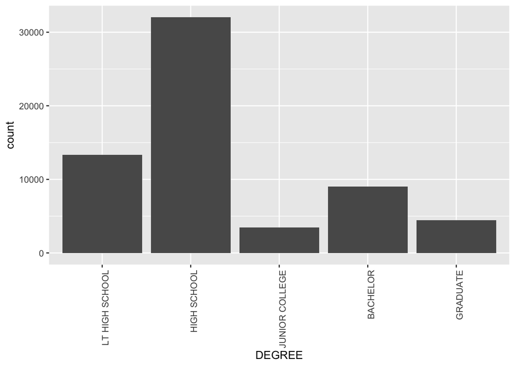

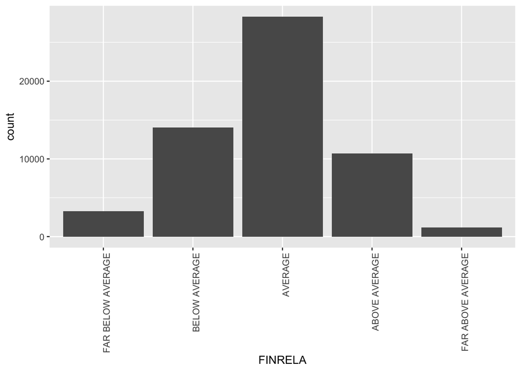

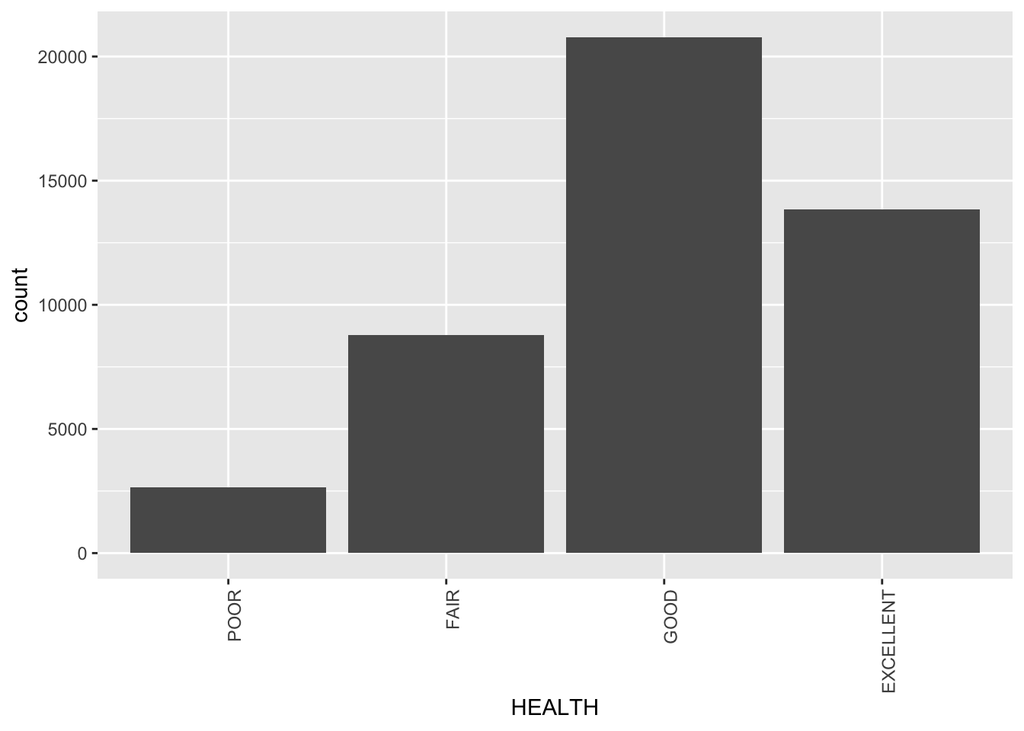

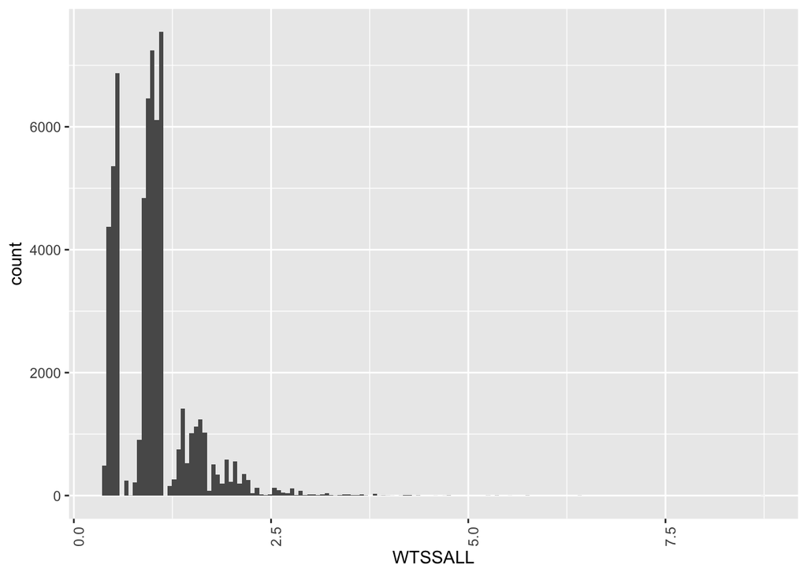

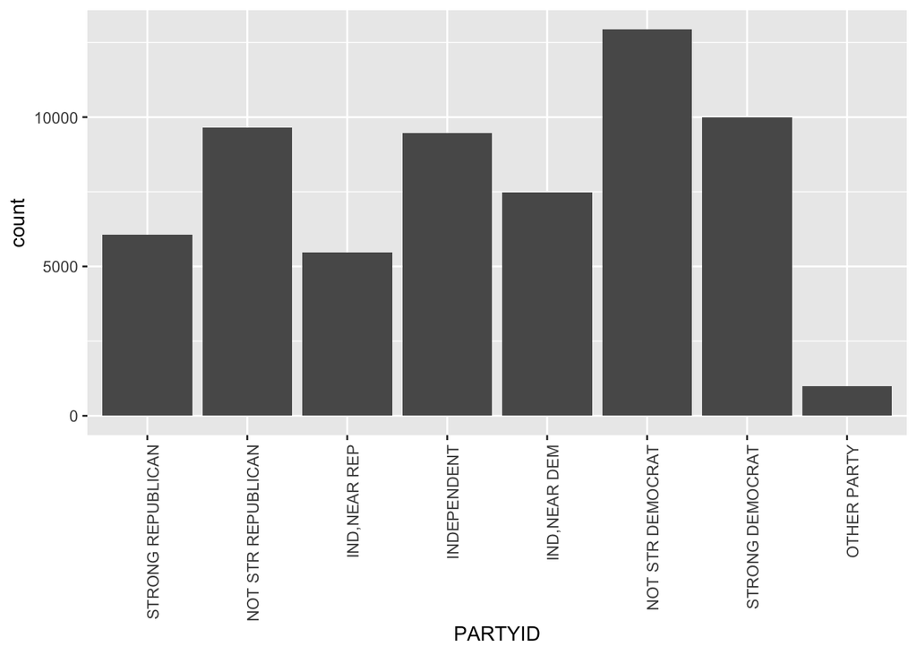

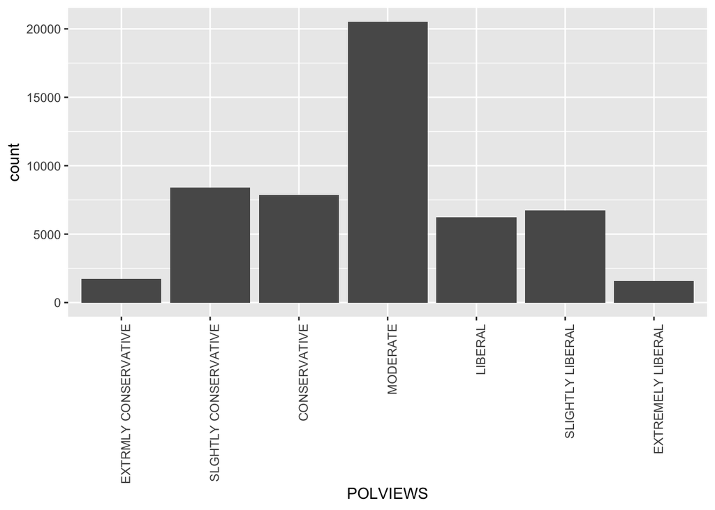

```r
for (column_index in 1:ncol(HAPPY)) {
  loop_subset <- HAPPY[, column_index]
  loop_subset <- loop_subset[!is.na(loop_subset)] #ignore NA values
  column_name <- names(HAPPY)[column_index]
  if (is.numeric(HAPPY[1, column_index])) {
    bw <- 2 * IQR(loop_subset) / length(loop_subset)^(1/3) #calculate ideal binwidth following Freedman-Diaconis rule
    #multiply binwidth by two to improve visual
    plot <- ggplot(HAPPY, aes_string(x=column_name)) +
      geom_histogram(binwidth = bw*2) + theme(axis.text.x = element_text(angle = 90, hjust = 1)) +
      xlab(column_name)
  }
  else {
    subset_df = data.frame(loop_subset)
    plot <- ggplot(subset_df, aes(x=subset_df[,1], na.rm = TRUE)) +
      geom_bar() + theme(axis.text.x = element_text(angle = 90, hjust = 1)) +
      xlab(column_name)
  }
  print(plot)
}
```

Use ggplot2 to create the plots. Your exploration should make use all elements of the grammar of graphics: mappings (color, fill, and size at least), different geoms (4 at least), scales, coordinates (eg coord_flip), facet, and theme (eg setting axis labels and title). For each investigation, create an appropriate visualization and write a paragraph to describe it.

1. Investigate the distributions of 2 different variables.

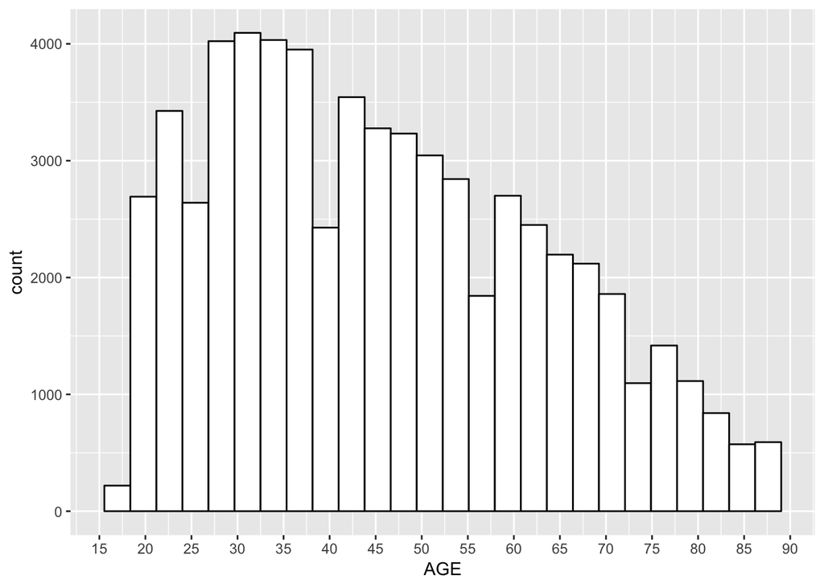

```r
#AGE distribution
age_subset <- HAPPY$AGE
age_subset <- age_subset[!is.na(age_subset)]
bw <- 2 * IQR(age_subset) / length(age_subset)^(1/3) #identical binwidth calculation used previously
plot1a <- ggplot(HAPPY, aes(x=AGE)) +
  geom_histogram(binwidth = bw*2, color="black", fill="white") + xlab("AGE") +
  theme(legend.position = "none") +
  scale_x_continuous(breaks=seq(15, 100, 5))

print(plot1a)
```

Age distribution is skewed right. The youngest age bin, containing individuals just over 15 years of age, has the lowest count. Individuals in early 30s were most frequently observed. A near linear depreciation of counted age exists from the maximum (age 30) to a local minimum count (age 85+).

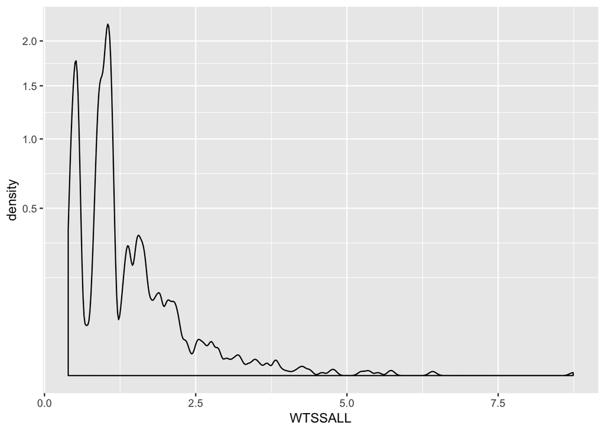

```r
#WTSSALL distribution
plot2a <- ggplot(HAPPY, aes(x=WTSSALL)) +
  geom_density() + xlab("WTSSALL") + scale_y_sqrt()

print(plot2a)
```

The WTSSALL variable is heavily skewed right In order to differentiate low density values, a square root treatment was applied to the y-axis. At small WTSSALL values, two large peaks of similar density were observed. The density signal quickly became near zero for larger WTSSALL values.

2. Investigate the relationship between happiness and three other variables in the data.

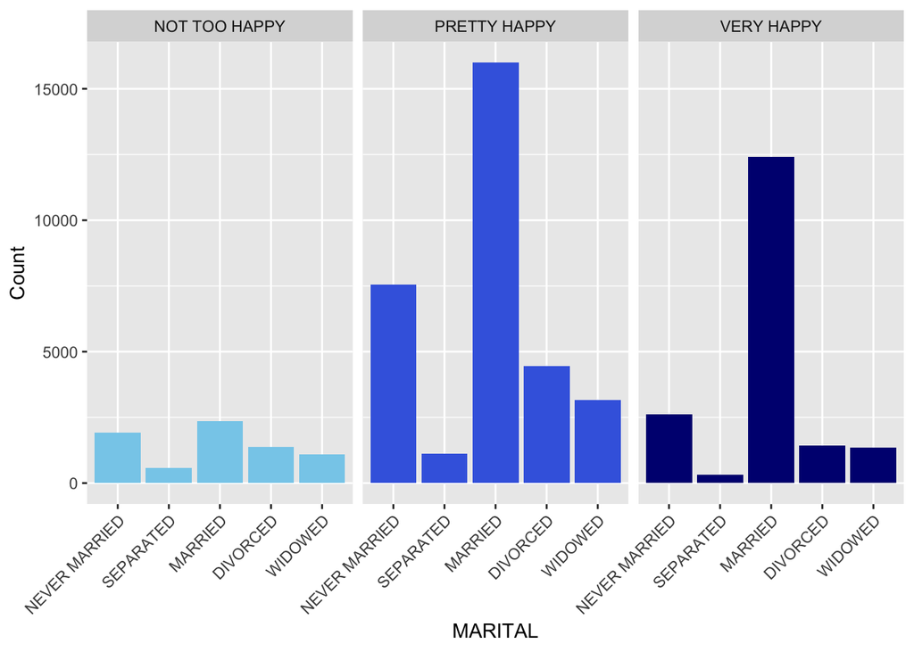

```r
#Marital status and happiness
subset_happy_marriage <- na.omit(HAPPY %>% select(HAPPY, MARITAL))
plot1b <- ggplot(subset_happy_marriage, aes(x=MARITAL, fill=HAPPY)) +
  geom_bar() + ylab("Count") +
  theme(axis.text.x = element_text(angle = 45, hjust = 1), legend.position = "none") +
  facet_wrap(~HAPPY) +
  scale_fill_manual(values = c("skyblue", "royalblue", "navy"), name = "Happiness")

#Age and happiness
subset_happy_age <- na.omit(HAPPY %>% select(HAPPY, AGE))
plot2b <- ggplot(subset_happy_age, aes(x=HAPPY, y=AGE)) +
  geom_point(alpha=0.05, position="jitter", aes(color=HAPPY), size=1) + geom_boxplot(alpha=0) +
  theme(legend.position = "none")

#Education and happiness
subset_happy_education <- na.omit(HAPPY %>% select(HAPPY, DEGREE))
plot3b <- ggplot(subset_happy_education, aes(x=DEGREE, fill=HAPPY)) +
  geom_bar(position = "fill") + ylab("Proportion") + coord_flip()

print(plot1b)
```

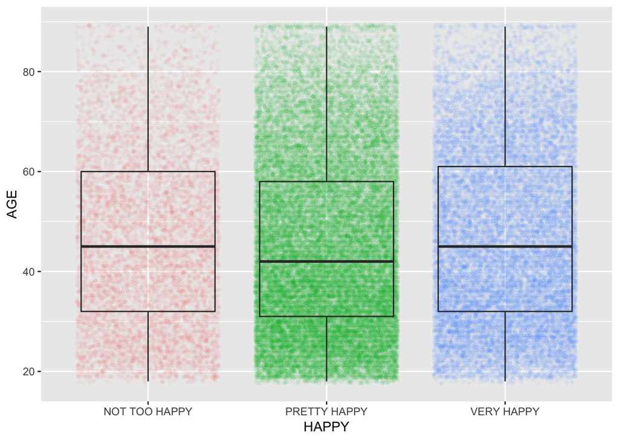

```r
print(plot2b)
```

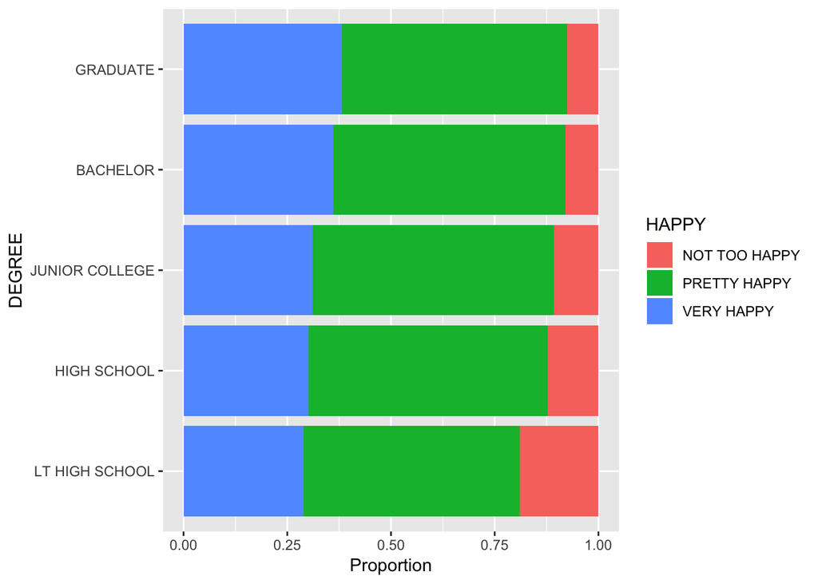

```r
print(plot3b)
```

3. What do you learn from the data set? Write one or two paragraphs to describe.

The happiness survey focused on an expected age distribution, although there was a minimum age restriction. Ages sampled were most frequent at adult prime (around age 30), and decreased in correspondence to human mortality. Happiness corresponded marginally with age.